# Exploratory Analysis

## Do You Have What It Takes to Become a Billionare in 2022?

### Authors

- Ayesha Patel (ayeshap3@uw.edu)
- Fal Iyoab (fali2003@uw.edu)
- Gillian Soekawan (gillms4@uw.edu)
- Jackie Hong (jmhong04@uw.edu)
- Megan Cuan (mcuan@uw.edu)

### Date

February 20, 2023

### Abstract

Our project will focus on identifying precursors for achieving a high economic status and assess who is being excluded from the billionaire economic class by investigating the question: “What common qualities or backgrounds do the top billionaires of 2022 share?” This question is important because income and wealth disparities are pressing issues both domestically and internationally. Included in this report will be data visualizations and summary statistics that highlight trends in characteristics describing one’s net worth.

### Keywords

Billionaires; Wealth; Social Class Mobility; Gender Wealth Disparity; Global Distribution of Wealth

### Introduction

Wealth is a vital determinant in the health, success, and security of one’s life. With greater wealth, not only does one have daily access to basic human necessities but also better healthcare benefits and reassurance of a sufficient income leading to longevity and tranquility. Yet, despite the great significance wealth has on the quality of life, there are large inconsistencies in the global [wealth distribution](https://www.cnbc.com/2023/01/16/richest-1percent-amassed-almost-two-thirds-of-new-wealth-created-since-2020-oxfam.html). From all of the wealth created since 2020, the richest 1% in the world own 67% of this new wealth (Kiderlin). Concerned with the unequal distribution of wealth, we wanted to analyze trends in the individuals who have the highest net worth globally in order to understand if this top-tier socioeconomic status is limited to specific characteristics or if it is a status that can be achieved by people from all backgrounds. This leads to our main research question:

- *What precursors do those with the highest net worth in the world have in common with one another?*

We broke down our main research question by considering how factors such as gender, age, country of origin (or state when looking only at the U.S.), and inherited wealth play a part in who is able to achieve an immense net worth. We also observed how this relates to one’s dedication to giving back to the less wealthy. Finally, we were curious about these billionaires’ industries in order to understand if a high net worth is correlated to working in a specific industry. All of these inquiries are reflected through the following research questions:

- *Does gender (as a binary variable) play a factor in a billionaire’s net worth?*
- *How does privilege/inherited wealth affect one’s ability to achieve high net worth?*
- *How does one’s country of origin (international factor) or state (domestic factor) relate to the chances of achieving a net worth in the billions?*
- *What are the common trends in billionaires who give back to society?*
- *What are the most and least common industries the world’s top billionaires are professionally involved in?*

By analyzing Forbes’ data on the World’s Billionaires in 2022, we will be able to analyze these billionaires’ traits and backgrounds and better understand what types of people have access to the world’s wealth.

### Related Work

Our topic is on 2022’s billionaires around the world and their characteristics and backgrounds. Here are related sources:

> “Billionaires around the World - Statistics & Facts.” Statista, Statista Research Department, 22 Sept. 2022, https://www.statista.com/topics/2229/billionaires-around-the-world/#topicOverview.
- Wealth disparity and distribution can be attributed to many factors, including gender and wealth mobility. This report by Statista is a good primer to preface how wealth is disproportionately spread. It states that almost half of the world’s wealth is owned by the richest 1% of all humans, that a majority of billionaires are older men who are self-made, while the minority of billionaires who are women are composed of those who inherited their wealth.

> Frank, Robert. “Why Aren’t There More Female Billionaires?” The New York Times, The New York Times, 30 Dec. 2016, https://www.nytimes.com/2016/12/30/business/why-arent-there-more-female-billionaires.html.
- This article offers insight into the gender disparity within wealth distribution in the United States specifically. Gabriel Zucman, an author of a paper on gender analysis of the top 1% of the richest people concluded, “The higher up you move in the income distribution, the lower the proportion of women” (Frank).

> Shiro,, Ariel Gelrud et all. “Stuck on the Ladder: Intragenerational Wealth Mobility in the United States.” Brookings. The Brookings Institution, 29 June 2022, https://www.brookings.edu/wp-content/uploads/2022/06/2022_FMCI_IntragenerationalWealthMobility_FINAL.pdf.
- This report by Brookings discusses the scope of social mobility in the context of different races, income levels, education levels, and age. Their analysis shows that upward mobility becomes less likely as individuals age while wealth mobility (both upwards and downwards) occur mostly when an individual is in their twenties to thirties. Another factor affecting wealth mobility is an individual’s education level. Among those who are born into the same wealth, bachelor degree holders end up accumulating much more wealth in their fifties as compared to their non-bachelor’s degree holders counterparts. On the other hand, in terms of race, they concluded that white Americans are more upwardly mobile and less downwardly mobile than their Black American counterparts. This report was a great indication that there are many determinants to the accumulation of wealth, including privilege, and uncontrollable factors such as race, age, and the ability to afford a higher education.

> Costa, Nicola. “The Economics of Billionaires.” Michigan Journal of Economics, 17 Nov. 2020, https://sites.lsa.umich.edu/mje/2020/11/17/the-economics-of-billionaires/.
- This journal describes the negative perceptions of billionaires and the wealth gap, the origin of billionaires from the “founding” of early capitalism, and their role in society today. One of the reasons the public is wary of billionaires is because they are concerned about how these people climbed up to such a high economic status, likely via unethical steps like tax evasion and lobbying. However, it’s important to note that billionaires create corporations that allow Americans to be productive, remain employed, and spend their money at other corporations. This was an important journal for us to read so that we do not approach the dataset with a bias against billionaires because they do have the ability to have a positive impact on the economy as long as they abide by the rules and do not engage in unethical methods to maintain their status.

### The Dataset

> Where did you find the data? Please include a link to the data source
- The dataset in a csv format was obtained from Kaggle at the following website: https://www.kaggle.com/datasets/prasertk/forbes-worlds-billionaires-list-2022?resource=download. The original source of the data is Forbes: https://www.forbes.com/billionaires/

> Who collected the data?
- Forbes. The main editor is Kerry A. Dolan and others include Bruce Upbin, Russell Flannery, Naazneen Karmali, Zina Moukheiber, Tatiana Serafin, and Susan Adams. The entire team is composed of more than 50 individuals that work together to collect and aggregate the data.

> How was the data collected or generated?
- According to an [article](https://www.forbes.com/sites/kerryadolan/2012/03/07/methodology-how-we-crunch-the-numbers/?sh=2f5e606cd3d8), Forbes generated the list using stock prices and exchange rates from March 11, 2022 (Dolan). Surveys were sent out to those who qualified for the list, with some who chose not to answer. To determine the net worth, they used intel gathered by dozens of reporters to estimate the value of individuals’ assets. To determine the philanthropic score, Forbes added the value of each individual’s total donations to the net worth, and divided their lifetime giving by that number. Each score corresponds to a number in a range, with 5 being most charitable and 1 being the least charitable. It should be mentioned this information was obtained from a source over 10 years old, however, Forbes has iterated they are constantly trying to improve their methodology in a [recent article](https://www.forbes.com/sites/chasewithorn/2022/09/27/2022-forbes-400-methodology-how-we-crunch-the-numbers/?sh=51080ec5d0eb) published about gathering data on American billionaires (Withorn).

> Why was the data collected?
- Forbes has been collecting this data yearly since 1987 to provide a snapshot of the world’s billionaires to the general public. Forbes’s role as a business magazine may contribute to its interest in measuring the world’s wealthiest individuals.

> How many observations (rows) are in your data?
- There are 2668 observations in the dataset.

> How many features (columns) are in the data?
- In the original dataset, there are 22 columns. We plan to use the following 13 columns: rank, person name, age, final worth, category, source, country, state, city, country of citizenship, self made, gender, and philanthropy score.

> What are possible limitations or problems with this data?
- After evaluating the dataset, one possible problem might arise due to the inclusion of both international and domestic data. This could cause difficulty in interpreting the results as a combined population because of the known differences between domestic versus international trends. It ultimately led us to our question “How does one’s country of origin (international factor) or state (domestic factor) relate to the chances of achieving a net worth in the billions?” through which we first examine trends in individual countries to identify and reduce the impact of cultural differences. Another possible limitation is the considerable number of “NA” values in the philanthropy score column. The lack of data limits our sample size for identifying trends among those who are charitable. Furthermore, it seems there are more “NA” values for billionaires who are not from the United States, suggesting the dataset is favoring United States billionaires over international ones. Limited data about those from countries other than the United States would cause our conclusions therefore to also favor US billionaires. Another possible limitation is the “self-made” category being represented as binary which may be an oversimplification. It is difficult to ascertain the level of power and influence the individual’s family may have had, leading to limited nuance and applicability of the results. Lastly, there are a few factors that are more informative in elucidating the realities of social mobility such as educational attainment, race, and the family’s relative economic class that Forbes chose not to investigate. If these factors were included in our dataset, the conclusions we would be able to draw about whether social mobility is attainable for the average person may be more specific and detailed.

### Implications

Through our research, we hope to provide answers about the common social factors among current billionaires. Our findings can help designers and technologists who work in research to design and share more detailed information about the make-up of billionaires beyond the standard factors of industry and net worth. Technologists could use our data to create a “how likely are you to be a billionaire” algorithm based on our findings about how gender, privilege, and country of origin affect these chances. Policy-makers, both on an international and domestic level, face increasing amounts of pressure and responsibility to address wealth inequality through public policies. Some of these policy decisions have been unfairly influenced by billionaires themselves who use their power to secure the status quo as Katherine Wiles’ article, “A big number that poses ethical questions” suggests, “‘Wealthy people’s policy preferences play a significant role in determining what policies are actually enacted, whereas the policy preferences of people who aren’t wealthy — and even people who are middle-class — have virtually no influence on actual policy outcomes,’” (Wiles, 2021). By instead focusing on data to make policy decisions, our findings can make policy-makers aware of whether they’re enforcing the status quo of who a billionaire is and what social class they come from. In order to better craft effective policies that curb an over-accumulation of wealth by a small and concentrated part of society, policy-makers can consider through our data who is being left out of these opportunities to accumulate wealth. Lastly, our focus on the trends in philanthropy among billionaires can help policy-makers evaluate what are the best methods to make sure billionaires are sharing their wealth.

### Limitations & Challenges

One of the main challenges with examining data about billionaires is determining the self-made status because of the subjective nature of the concept. For example, those who are born into a wealthy family but worked hard to build their own successful career might consider themselves self-made, such as the Kardashians, while others might argue that their upbringing gave them an unfair advantage. There are certain individuals who are excluded from billionaires’ lists, such as those who have acquired wealth through political power or hereditary privilege. For example, corrupt political leaders like Kim Jong Un or members of royal families may have access to vast resources and opportunities that are not available to the general population. Additionally, individuals who have acquired wealth through unethical or illegal means, such as embezzlement, exploitation of natural resources, or human rights abuses are also typically excluded from such lists. Billionaire data often doesn’t incorporate intangible, metaphysical elements in what brought a person to become a billionaire. We do not know how hard a person worked, the intensity of their desire to accumulate wealth, and other potential psychological factors that would greatly affect one’s ability to achieve economic success. This is because of the difficulty in quantifying and ensuring the data remain consistent. Because we don’t have access to all of this information, it is difficult to reach conclusions that apply to the whole population.

### Summary Information

The Forbes Top World Billionaires List of 2022 includes 2668 billionaires from around the world. When calculating the average age among the billionaires, it was 64. From this data, we are also able to calculate the breakdown of gender, privilege, location, and philanthropy scores to see who is in the majority. After calculating the gender make-up of the 2022 billionaire list, the proportion of men is greater than the proportion of women. The proportion of women was 0.1165667 while the proportion of men was 0.8774363, nearly eight times higher than the proportion of women. Interestingly, when calculating the proportions of privilege, the proportion of billionaires with inherited wealth, 0.2912294, is significantly lower than the proportion of self-made billionaires, 0.7087706. The country with the highest number of billionaires was United States. And, the state within the U.S with the highest number of billionaires was California. The average philanthropy score among billionaires in the United States was 1.8622449 out of a scale of 5.

### Table

Billionaire Data by Industry

| Industry | Average Net Worth (in Billions) | Average Age | Proportion of Women | Proportion of Self-Made |
| --- | --- | --- | --- | --- |
| Automotive | 8.34 | 63.60 | 0.06 | 0.59 |
| Fashion & Retail | 6.47 | 67.40 | 0.13 | 0.62 |
| Technology | 6.36 | 56.05 | 0.09 | 0.94 |
| Metals & Mining | 5.75 | 59.85 | 0.13 | 0.71 |
| Logistics | 5.61 | 67.85 | 0.09 | 0.71 |
| Telecom | 5.60 | 64.62 | 0.03 | 0.89 |
| Diversified | 5.23 | 68.47 | 0.16 | 0.46 |
| Media & Entertainment | 5.03 | 62.88 | 0.10 | 0.72 |
| Gambling & Casinos | 4.68 | 67.61 | 0.17 | 0.83 |
| Food & Beverage | 4.61 | 65.99 | 0.19 | 0.54 |
| Finance & Investments | 4.44 | 64.50 | 0.07 | 0.76 |
| Energy | 4.18 | 66.81 | 0.09 | 0.75 |
| Sports | 3.65 | 71.33 | 0.11 | 0.70 |
| Real Estate | 3.57 | 67.59 | 0.11 | 0.73 |
| Service | 3.55 | 67.67 | 0.15 | 0.57 |
| Healthcare | 3.29 | 63.92 | 0.16 | 0.71 |
| Manufacturing | 3.25 | 63.42 | 0.13 | 0.72 |
| Construction & Engineering | 2.69 | 65.22 | 0.13 | 0.54 |

This table groups 2022’s billionaires by the industry they work in. Furthermore, it shows the average net worth and age of the billionaires as well as the proportion of women and proportion of self-made billionaires **per industry**. The average net worth is then displayed from greatest to least in order to show, on average, which industries contain the billionaires with the highest net worth. We chose to group our aggregate table by industry because we wanted to determine if a certain industry was associated with a higher net worth or if a billionaire’s net worth was the same regardless of the industry. We also wanted to understand how some of the factors we addressed in our research questions (such as age, gender, and privilege) played out in the industries with the most successful billionaires instead of only viewing how these factors play out among all billionaires.

This table reveals that the Automotive, Fashion & Retail, and Technology industries are the top three industries with billionaires who have the highest average net worth. The table reveals that the average ages across all of the industries are very similar to each other, which suggests that the billionaire’s economic status might be correlated with an age around 60 years of age regardless of industry. The proportion of women in each industry is extremely low and never exceeds 0.2 revealing a low proportion of women billionaires across all industries. The proportion of billionaires who are self-made is highest in the Technology industry at 0.94 and lowest in the Diversified industry at 0.46 suggesting that there is more economic mobility in the technology industry.

### Chart 1

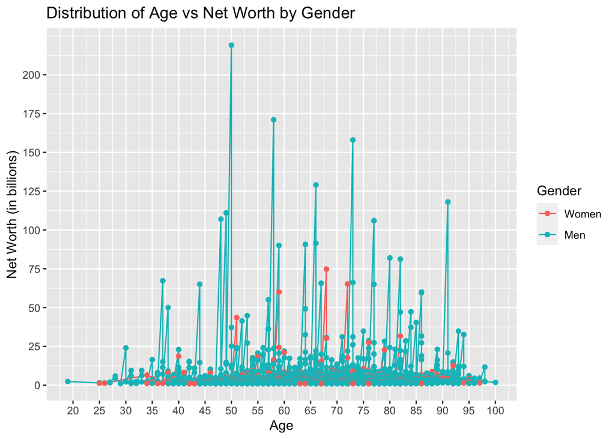

The purpose of this combined scatterplot and line plot is to show the net worth for women and men across different ages. It highlights whether age is in fact, correlated with net worth and whether this trend differs between men and women. It seeks to answer our questions about the extent to which age and gender have an effect on one’s ability to acquire wealth. The scatter plot aspect of the visualization emphasizes outliers and shows the general trend while the line plot aspect of the visualization increases readability.

This visualization shows that billionaires aged 55 to 75, on average, seem to have higher net worths. There is, however, an outlier at age 50 with the highest net worth at upwards of 200 billion. Excluding the outlier, the billionaire that is man with the highest net worth is around 57 years old while the billionaire that is a woman with the highest net worth is around age 67. It seems that billionaires that are women, as a whole, have lower net worths than billionaires that are men. The wealthier women billionaires are generally older than the wealthier men billionaires suggesting that billionaires who are women acquire wealth when they’re older. Overall, it appears that older men hold the majority of the world’s wealth.

### Chart 2

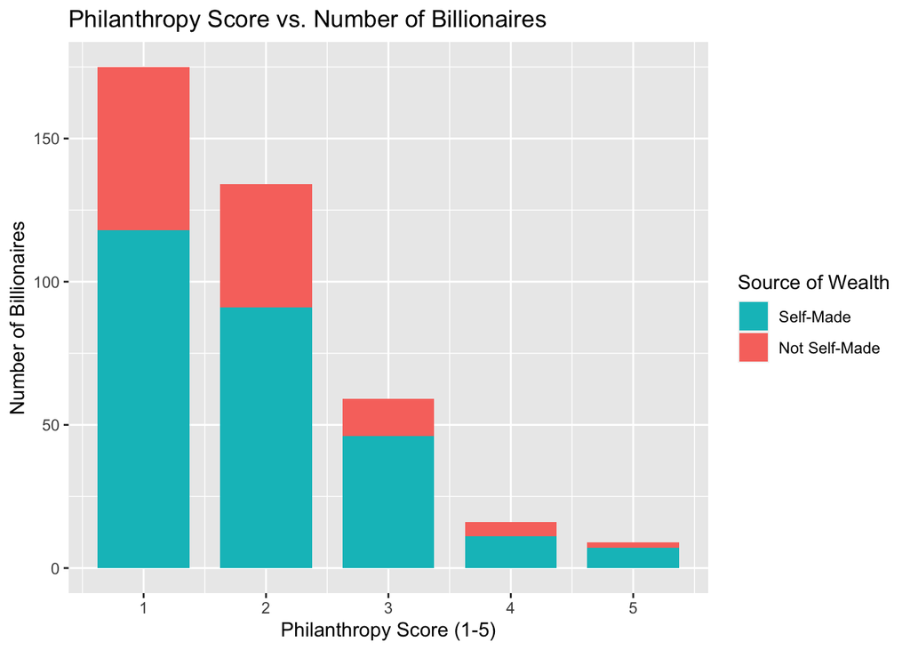

This stacked bar chart aims to demonstrate the correlation between billionaires’ source of wealth and privilege, specifically whether or not they are self-made, and their philanthropy score. The philanthropy scores were determined by the value of a billionaire’s donations throughout their life in ratio to the sum of their total donations and net worth. From a scale of 1 to 5, 1 is the least charitable while 5 is the most charitable.

### Chart 3

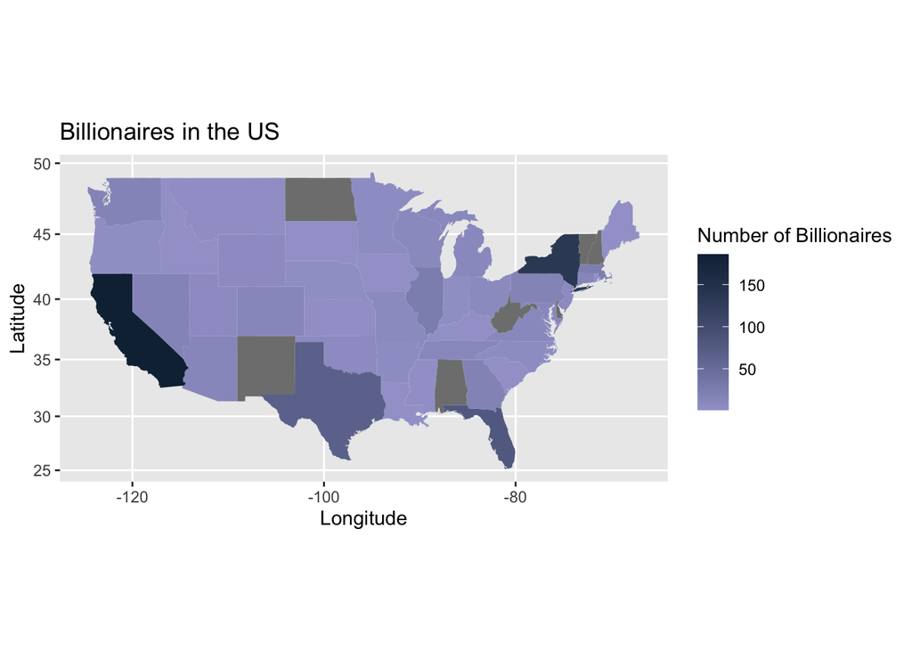

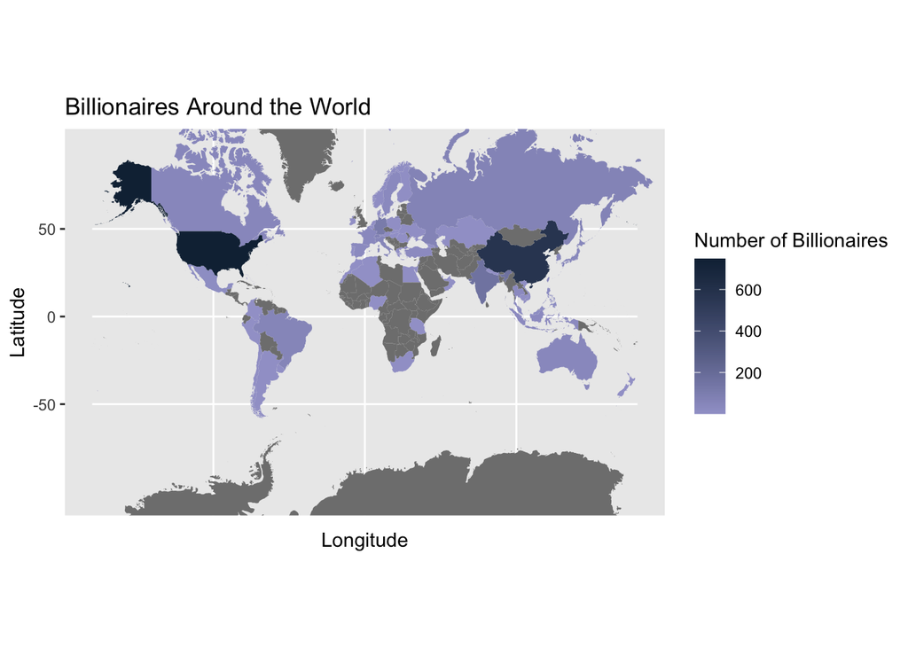

These density maps are color-coded to represent the density of a particular variable across a given area. In the case of a density map of billionaires, the map uses color gradients to show where the highest concentrations of billionaires are located.

The world density map of billionaires shows the distribution of billionaires across different regions and countries. This map is helpful in highlighting the countries with the highest number of billionaires, such as the United States and China.

Zooming in on the United States specifically, this density map shows the distribution of billionaires across the country’s various states (and excludes Hawaii, Alaska, and U.S. territories). This map is useful in highlighting the areas with the highest concentration of billionaires, such as California and New York. It also shows the areas with the lowest concentration of billionaires, such as rural states in the Midwest and South.

By using a color-coded scale to represent the density of billionaires in different areas, these density maps make it easy to quickly understand where billionaires are concentrated and where they are not. This information can be useful for a variety of purposes, such as market research, policy analysis, and social science research.

### Acknowledgements

> We would like to thank our phenomenal teaching assistant Beth Gronski for her guidance and support. We would also like to thank our amazing professor, Professor Melanie Walsh for her informative and engaging learning material.

### References

“Billionaires around the World - Statistics & Facts.” Statista, Statista Research Department, 22 Sept. 2022, https://www.statista.com/topics/2229/billionaires-around-the-world/#topicOverview.

Costa, Nicola. “The Economics of Billionaires.” Michigan Journal of Economics, 17 Nov. 2020, https://sites.lsa.umich.edu/mje/2020/11/17/the-economics-of-billionaires/.

Dolan, Kerry A. “Methodology: How We Crunch the Numbers.” Forbes, Forbes Magazine, 20 June 2012, https://www.forbes.com/sites/kerryadolan/2012/03/07/methodology-how-we-crunch-the-numbers/?sh=2f5e606cd3d8.

Frank, Robert. “Why Aren’t There More Female Billionaires?” The New York Times, The New York Times, 30 Dec. 2016, https://www.nytimes.com/2016/12/30/business/why-arent-there-more-female-billionaires.html.

Kiderlin, Sophie. “The Richest 1% of People Amassed Almost Two-Thirds of New Wealth Created In the Last Two Years, Oxfam Says.” CNBC, NBCUniversal News Group, 16 Jan. 2023, https://www.cnbc.com/2023/01/16/richest-1percent-amassed-almost-two-thirds-of-new-wealth-created-since-2020-oxfam.html.

Peterson-Withorn, Chase. “2022 Forbes 400 Methodology: How We Crunch the Numbers.” Forbes, Forbes Magazine, 8 Nov. 2022, https://www.forbes.com/sites/chasewithorn/2022/09/27/2022-forbes-400-methodology-how-we-crunch-the-numbers/?sh=51080ec5d0eb.

Shiro, Ariel Gelrud et al. “Stuck on the Ladder: Intragenerational Wealth Mobility in the United States.” Brookings. The Brookings Institution, 29 June 2022, https://www.brookings.edu/wp-content/uploads/2022/06/2022_FMCI_IntragenerationalWealthMobility_FINAL.pdf.

Wiles, Katherine. “A Big Number that Poses Big Ethical Questions.” Marketplace, Minnesota Public Radio, 15 Apr. 2021, https://www.marketplace.org/2021/04/15/should-there-be-billionaires-ethical-question/.